# Анализ данных

# **Анализ данных по проектам Kickstarter**

# **Предобработка и подготовка данных**:

- преобразование переменных типа character в тип factor, чтобы можно было использовать статистические тесты и строить модель дерева
- преобразование переменной launched в формат Date, чтобы можно было выполнять операции над датами
- создание новых переменных для анализа

*новые переменные на основе launched:* месяц запуска(month),день запуска(day),сезон запуска(launch_season), день недели запуска(launch_weekday),час запуска(launch_hour), часть дня, во время которой запустили сборы(launch_dayPart-), длительность сборов(period_length)

*новые переменные на основе category и main_category:* gen_category-переменная, содержащая информацию одновременно про main_category и category, есть ли точное совпадение названия категории и основной категории(cat_is_cat), длина в символах переменной category и gen_category (cat_length и gen_cat_length соответственно), количество слов в переменной category и gen_category (cat_number_words и gen_cat_number_words), первая буква названия в переменных category и gen_category(cat_first_letter, gen_cat_first_letter)

*новые переменные на основе name:* длина строки названия в символах(name_length), количество слов в названии(number_of_words),есть ли слова, написанные КАПСОМ(has_caps_in_name), количество слов, написанных КАПСОМ(n_caps_in_name), есть ли символы “:”,“!”,“;” в названии (name_has_marks)

# **Разведочный анализ**

##### Самое очевидно различие между проектами - это их принадлежность к различным категориям. Поэтому вопросы, на которые я буду искать ответ в первой части, звучат так:

- **1) В каких категориях реализованы самые дорогие проекты?**
- **2)В каких категориях наиибольший процент удачных проектов?**

**В каких категориях реализованы самые дорогие проекты?**

| Основная категория | Средняя сумма реализованных проектов |
| --- | --- |
| Technology | 23680.1 |
| Design | 14234.7 |
| Food | 12833.4 |
| Film & Video | 11476.1 |
| Games | 10807.5 |
| Journalism | 9465.3 |
| Photography | 8307.8 |
| Fashion | 7416.9 |
| Music | 6867.9 |
| Publishing | 6769.5 |
| Theater | 5470.5 |
| Dance | 5230.5 |
| Comics | 4755.8 |
| Art | 3869.8 |
| Crafts | 3201.6 |

Как мы видим, Технологии, Дизайн и Еда входят топ-3 категории с самыми дорогими реализованными проектами

**В каких категориях наиибольший процент удачных проектов?**

| Основная категория | Процент успешных проектов |
| --- | --- |
| Comics | 68.96936 |
| Dance | 62.57669 |
| Theater | 60.37267 |
| Games | 52.76447 |
| Music | 49.55336 |
| Design | 49.24755 |
| Art | 48.95166 |
| Film & Video | 41.03560 |
| Publishing | 39.97332 |
| Photography | 39.41769 |
| Fashion | 33.14038 |
| Crafts | 30.49808 |
| Food | 26.12679 |
| Technology | 24.78103 |
| Journalism | 23.92996 |

**Построим график, иллюстрирующий успешность проектов в разных категориях**

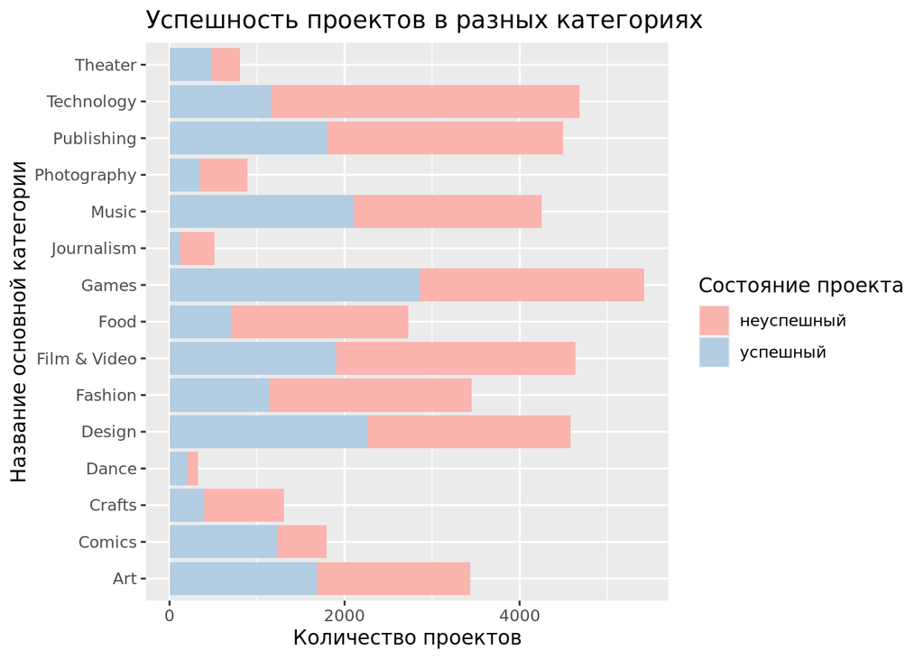

А какие результаты будут, если мы будем рассматривать не общие категории, а подкатегории? Для этого воспользуемся созданной дополнительной переменной gen_category, которая объединяет в себе информацию про main_category и category. Поскольку, подкатегорий получается намного больше, чем категорий, в таблице отобразим первые 10 по сумме, указанной в цели проекта.

| Подкатегория | Средняя сумма успешных проектов |
| --- | --- |
| Film & Video, Movie Theaters | 54570.7 |
| Technology, Camera Equipment | 35483.0 |
| Technology, Hardware | 34955.9 |
| Design, Civic Design | 33841.9 |
| Technology, Wearables | 33091.0 |
| Technology, Robots | 31136.0 |
| Technology, 3D Printing | 29982.0 |
| Technology, Fabrication Tools | 26479.2 |
| Technology, Technology | 24692.6 |
| Games, Video Games | 23109.0 |

Мы видим, что средняя успешно собранная сумма намного выше, чем в предыдущем случае, к тому же теперь на первых местах подкатегории Film & Video , Movie Theaters; Technology , Camera Equipment;Technology , Hardware

**Какой будет процент успешности проектов в подкатегориях?** Поскольку подкатегорий у нас получилось достаточно много, для графика отберем топ-15 с наибольшим количеством проектов.

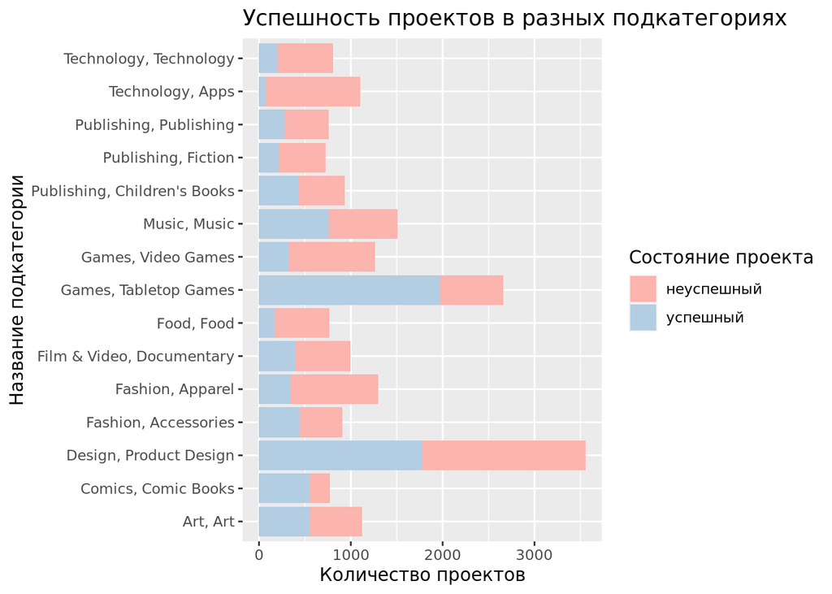

Как мы видим, при учете подкатегорий мы можем увидеть больше деталей. Например, категория games в предыдущем графике показывала 53% успешности, однако благодаря разделению на подкатегории, мы видим, что Video Games понижает средний процент успешности категории, в то время как Tabletop Games повышает. Иными словами, разделение становится более детальным, следовательно точность нашего предсказания успешности проекта возрастет. Давайте подтвердим это утверждение статистическими тестами.

#### Гипотезы:

- **H0:** Разница в успешности проектов, распределенным по переменным category/main_category/gen_category статистически незначима
- **H1:** Разница в успешности проектов, распределенным по переменным category/main_category/gen_category статистически значима

```
##
##  Asymptotic General Independence Test
##
## data:  category by state (failed, successful)
## maxT = 34.012, p-value < 2.2e-16
## alternative hypothesis: two.sided
```

```
##
##  Asymptotic General Independence Test
##
## data:  gen_category by state (failed, successful)
## maxT = 34.012, p-value < 2.2e-16
## alternative hypothesis: two.sided
```

```
##
##  Asymptotic General Independence Test
##
## data:  main_category by state (failed, successful)
## maxT = 26.003, p-value < 2.2e-16
## alternative hypothesis: two.sided
```

Во всех случаях, P-value<0.05, следовательно мы не можем принять нулевую гипотезу и принимаем гипотезу H1: Разница в успешности проектов, распределенным по переменным category/main_category/gen_category статистически значима

В начале мы создали несколько переменных, основанных на категориях и подкатегориях: есть ли точное совпадение названия категории и основной категории(cat_is_cat), длина в символах переменной category и gen_category (cat_length и gen_cat_length соответственно), количество слов в переменной category и gen_category (cat_number_words и gen_cat_number_words), первая буква названия в переменных category и gen_category(cat_first_letter, gen_cat_first_letter). Возможно, эти переменные могут быть использованы для построения модели.

**Мини-вывод:** процент успешности в категориях и подкатегориях раличается, следовательно переменные связанные с разбиением по категориям и подкатегориям теоретически дадут неплохое разбиение для дерева.

**Попробуем ответить на такой вопрос:есть ли связь между числом и месяцем запуска проекта и его успешностью?**

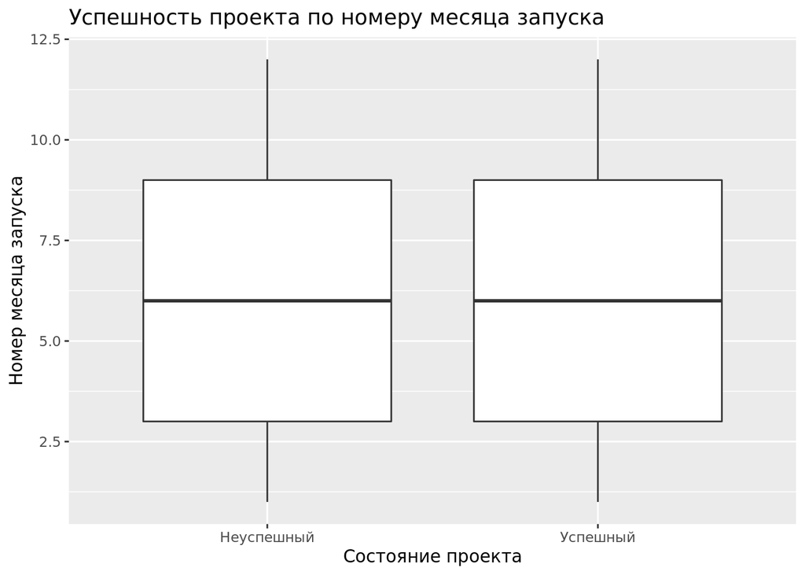

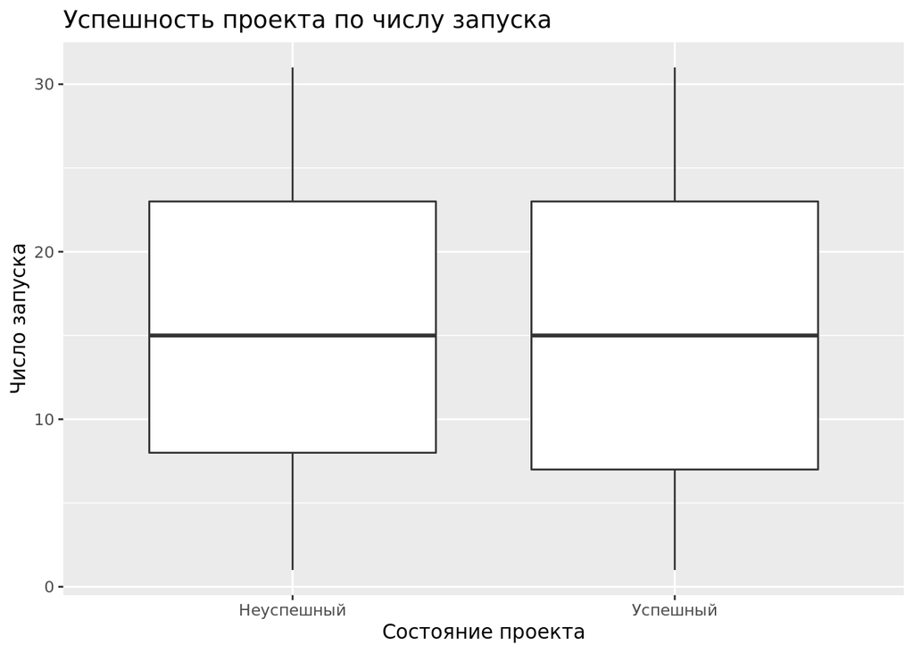

Боксплоты показывают, что связи скорее всего нет, поскольку “коробочки” и медианы почти одинаковые в обоих случаях. А что покажут статистические тесты?

**1-й тест**:

- **H0:** Разница между средним значением месяца между группами успешных и неуспешных проектов статистически незначима
- **H1:** Разница между средним значением месяца между группами успешных и неуспешных проектов статистически значима

```
##
##  Welch Two Sample t-test
##
## data:  month by state
## t = -4.0057, df = 39315, p-value = 6.196e-05
## alternative hypothesis: true difference in means is not equal to 0
## 95 percent confidence interval:
##  -0.18421348 -0.06316673
## sample estimates:
##     mean in group failed mean in group successful
##                  5.92010                  6.04379
```

P-value<0.05, следовательно мы не можем принять нулевую гипотезу и принимаем гипотезу H1: Разница между средним значением месяца между группами успешных и неуспешных проектов статистически значима

**2-й тест**:

- **H0:** Разница между средним значением дня между группами успешных и неуспешных проектов статистически незначима
- **H1:** Разница между средним значением дня между группами успешных и неуспешных проектов статистически значима

```
##
##  Welch Two Sample t-test
##
## data:  day by state
## t = 5.5089, df = 39419, p-value = 3.634e-08
## alternative hypothesis: true difference in means is not equal to 0
## 95 percent confidence interval:
##  0.3082645 0.6487745
## sample estimates:
##     mean in group failed mean in group successful
##                 15.43359                 14.95507
```

P-value<0.05, следовательно мы не можем принять нулевую гипотезу и принимаем гипотезу **H1: Разница между средним значением дня между группами успешных и неуспешных проектов статистически значима**

**Мини-вывод:** статистические тесты показали, что разница статистически значима, однако всё равно она очень мала. Следовательно, мы можем использовать эти переменные для построения дерева, но скорее всего, эти переменные не смогут дать хорошего разбиения, что частично подтверждается графиками боксплот.

### **Анализ переменных на основе launched**

Идея с днями и месяцами не оказалось успешной, попробуем поработать со следующими переменными, на основе launched: сезон запуска(launch_season), день недели запуска(launch_weekday),час запуска(launch_hour), часть дня, во время которой запустили сборы(launch_dayPart), длительность сборов(period_length)

**Есть ли какая-либо зависимость между этими переменными и успешностью проекта?**

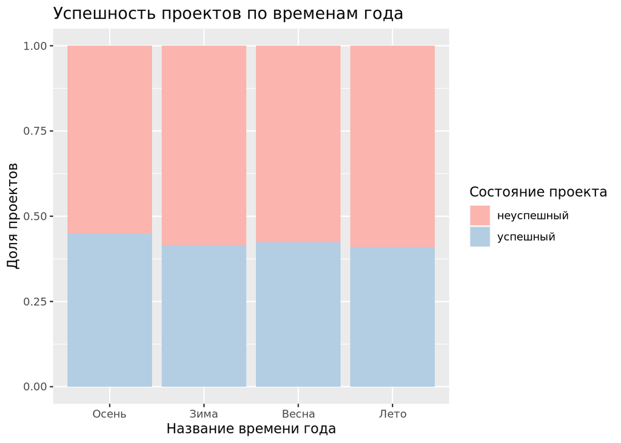

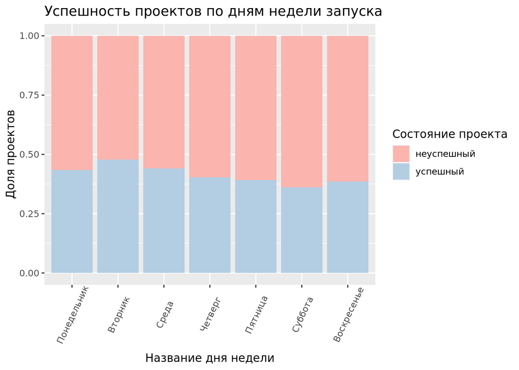

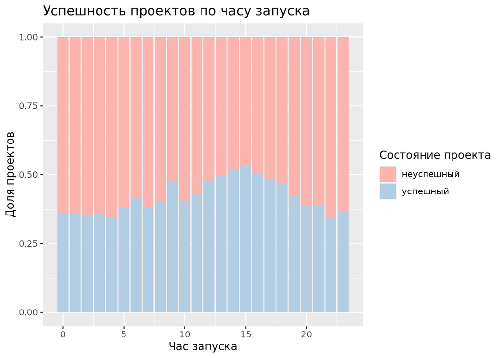

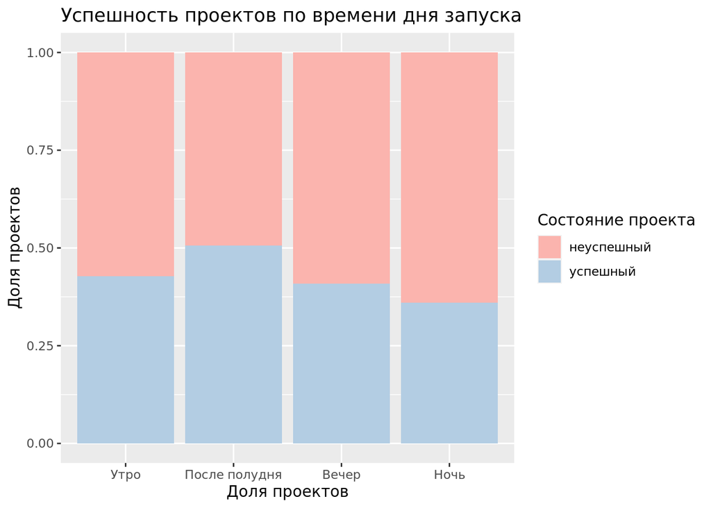

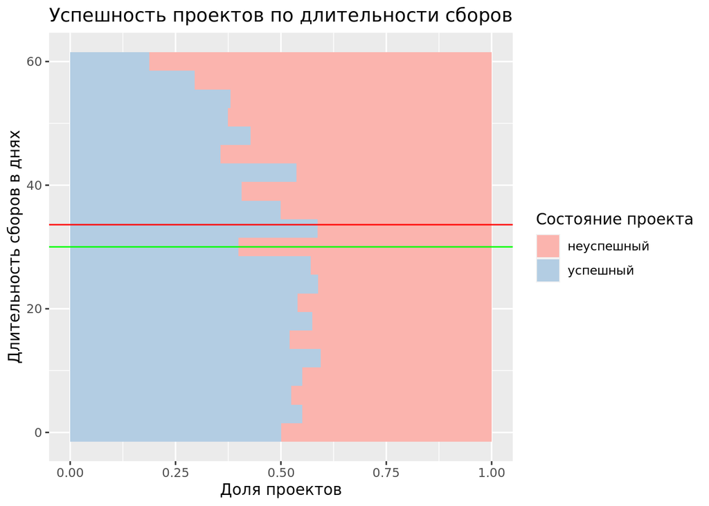

## **Выводы на основании графиков**:

- Успешность проектов по временам года: во все времена года процент успешности проектов примерно одинаков, он чуть-чуть повышается осенью
- Успешность проектов по дням недели запуска : начиная со вторника, процент постепенно успешных проектов постепенно уменьшается, с субботы по вторник повышается
- Успешность проектов по часу запуска и по времени дня запуска: из обоих графика ясно видно, что время после полудня благоприятствует успеху проекта.
- Успешность проектов по длительности сборов:красным обозначена линияя средней длительности неуспешного проекта, зеленым- успешного. По графику видно, что по мере того как длительность сбора превышает 30 дней, процент успешности проектов постепенно падает. В то же время, когда длительность сборов возрастает 30 дней, четкой тенденции к повышению/понижению процента успешности не наблюдаются, изменения незначительны. Также видно, что средняя длительность успешного проекта ниже, чем неуспешного.

### **Анализ переменных,созданных на основе названия проекта (name)**

Последняя часть разведочного анализа посвящена анализу переменных, созданных на основе названия проекта (name). А именно: длина строки названия в символах(name_length), количество слов в названии(number_of_words),есть ли слова, написанные КАПСОМ(has_caps_in_name), количество слов, написанных КАПСОМ(n_caps_in_name), есть ли символы “:”,“!” в названии (name_has_marks)

**Есть ли какая-либо зависимость между этими переменными и успешностью проекта?**

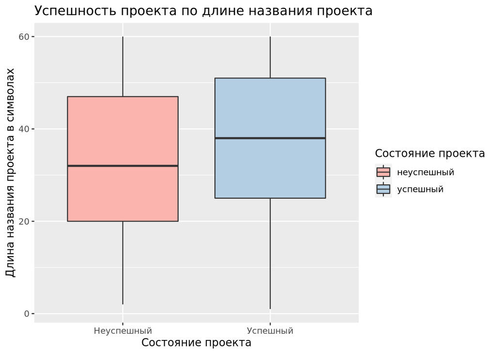

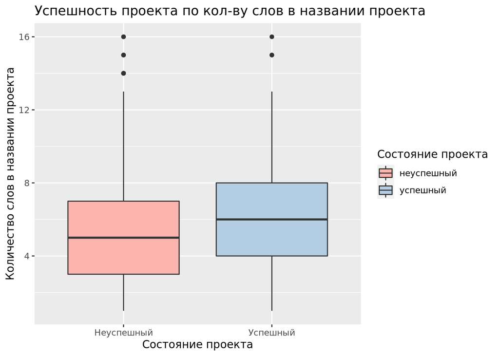

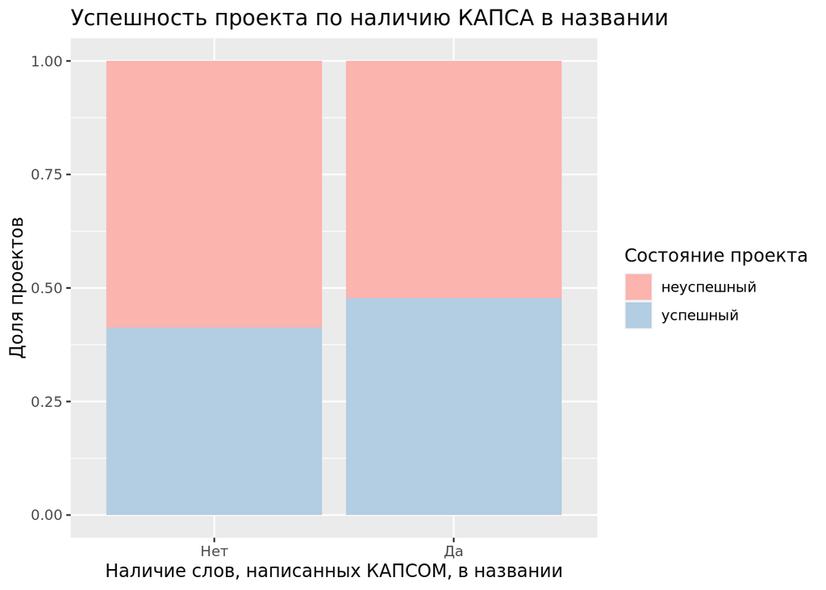

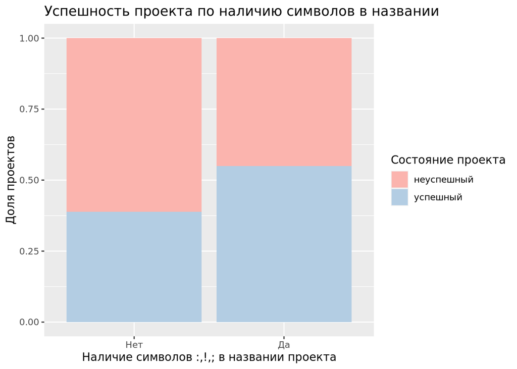

## **Выводы по графикам**:

- Успешность проекта по длине названия проекта и по кол-ву слов в названии: проекты с более длинным названием и большим кол-вом слов в названии имеют тенденцию быть более успешными
- Успешность проекта по наличию КАПСА и определенных символов в названии: доля успешных проектов больше в группе, где название содержит слова, написанные КАПСОМ и символы :,!,;

# **Статистические тесты**

Проведем серию статистических тестов для переменных, по которым мы собираемся строить модель. Для категориальных и логических переменных будем использовать independence_test и chisq_test, в том случае, когда переменная числовая - t.test. Исходя из значений p-value, каждое из которых меньше 0.05, мы убедились, что можем использовать эти переменные для построения дерева. (код с отображением результатов теста в отчете скрыт)

# **Общие выводы по разведочному анализу:**

- Успешность различается в разных категориях и подкатегориях(что подтверждается статистическими тестами), поэтому разделение на основе этих и созданных на их основе переменных может оказаться полезным в создании модели
- Согласно статистическим тестам, число и месяц запуска проекта является статистически значимыми переменными в связи с успешностью проекта, однако различия в группах малы, поэтому скорее всего эти переменные не будут иметь значения в построении дерева
- Различие в успешности проектов по временам года имеется, но скорее всего незначительно для будущей модели
- Час запуска и время дня запуска проекта являются полезными переменными для дерева
- Благоприятное время запуска проекта - после полудня, с 12 по 18 часов
- Чем больше длительность сборов (если больше 30 дней), тем меньше вероятность успеха проекта. Длительность сборов - полезная переменная для разделения
- Длина названия, кол-во слов в названии, слова, написанные КАПСОМ и наличие символов :,!,; положительно влияют на успешность проекта. Следовательно, могут служить неплохими переменными для разделения

# **Построение модели**

**Разделим выборку на части**

## Построение сложной модели

Попробуем построить сложную модель, которая даст нам наибольшую точность. Будем использовать пакет rpart и все переменные, кроме id, name, date, deadline, launched, backers, launch date.

### Необрезанное дерево

[figure not shown]

**accuracy на тренировочной выборке**

```
## [1] 0.7031845
```

**accuracy на тестовой выборке**

```
## [1] 0.6827045
```

Как мы видим, accuracy на тестовой выборке получилась ниже, но незначительно. Обрежем дерево по оптимальному значению cp

**строим таблицу cp** (код с таблицей cp и оптимальным значением cp в отчете скрыт)

**обрезаем дерево через prune()**

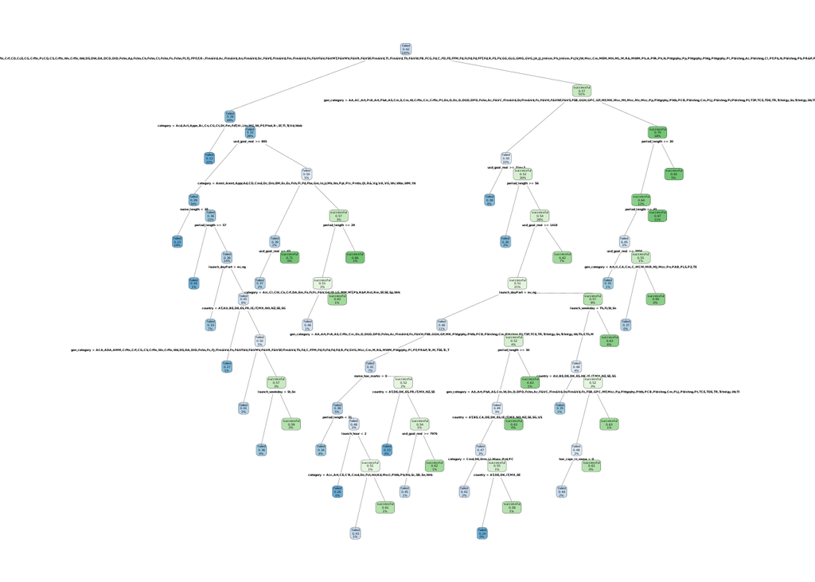

**accuracy для тренировочной выборки**

```
## [1] 0.7018865
```

**accuracy для тестовой выборки**

```
## [1] 0.6823584
```

Итак, мы построили сложную модель и достигли точности 0.7018865 на тренировочной и 0.6823584 для тестовой выборки. Попробуем построить менее сложную модель, но при этом попробуем достигнуть сходной точности. Для этого с помощью команды summary посмотрим, какие переменные модель 1 посчитала наиболее важными и построим модель на их основе.

## Построение менее сложной модели

**модель и accuracy для тренировочной выборки**

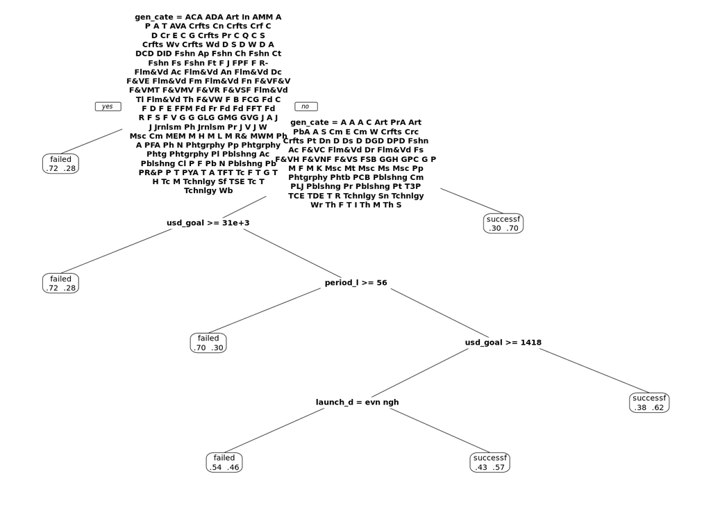

```
## [1] 0.6758971
```

**accuracy для тестовой выборки**

```
## [1] 0.6693204
```

Итак, мы построили намного более простую модель, имеющую точность 0.6758971 для тренировочной и 0.6693204 для тестовой выборок.

```
## [1] "При этом, точность упрощенной модели на 2.6 % (тренировочная выборка) и  1.3 % (тестовая выборка) ниже, чем у на порядок более сложной модели"
```

### **Какие группы исследованы и почему:**

Мы исследовали группы, разделенные по многим переменным. В первую очередь, группы, разделенные по переменным, связанными с категориями (category,main_category и др.), поскольку эта классификация изначально присутствовала в данных и,как оказалось, процент успешности в разных категориях и подкатегориях различается. Поэтому мы пошли глубже и создали дополнительные переменные по категориям, которые впоследствии использовались в модели. Также мы исследовали группы, разделенные по сезонам, месяцам, дням, дням недели. Статистические тесты показали, что разница в успешности по этим переменным статистически значима, однако графики показали, что разница достаточно незначительна. Группы, разделенные на основе часа и времени дня запуска, были исследованы, поскольку графики показали различия в группах и тенденцию проекта быть более успешным, если он был запущен во время после полудня. Дополнительно, мы исследовали группы по переменным на основе названия проекта(длина названия, кол-во слов в названии, наличие слов, написанных капсом, наличие определенных символов в названии), поскольку из графиков мы увидели существенные различия у успешности проекта.

#### **Первая модель**

Первая модель разделила данные на большое кол-во групп, поэтому приведем лишь названия переменных и их значимость для модели.

| Переменная | Расшифровка названия | Значимость |
| --- | --- | --- |
| category | категория | 25 |
| gen_category | категория и подкатегория проекта | 22 |
| main_category | основная категория | 12 |
| cat_first_letter | первая буква названия категории | 11 |
| gen_cat_first_letter | первая буква названия подкатегории | 10 |
| cat_length | длина названия категории в символах | 7 |
| usd_goal_real | целевая сумма проекта в долларах | 4 |
| period_length | длительность сборов | 3 |
| name_length | длина названия проекта в символах | 1 |
| country | страна | 1 |
| launch_dayPart | часть дня, в которую был запущен проект | 1 |
| number_of_words | количество слов в названии проекта | 1 |
| currency | валюта | 1 |
| launch_hour | час запуска | 1 |

### **Какие предсказания в каких группах получились**

**Упрощенная модель разделила все проекты на 7 групп**. При этом модель составила два списка подкатегорий: в первый вошли такие подкатегории, как Art, Conceptual Art;Art, Digital Art; Crafts, Candels и другие - в этом списке оказались подкатегории, в которых проект чаще был неуспешным чем успешным. Во второй список вошли подкатегории, в которых процент успеха был выше (Например, Technology, Robots; Theater, Musical и другие)

##### **Группы**:

- **1-я группа:** проект относится к категории из 1-го списка. **Предсказание: неуспешный**
- **2-я группа:** проект не относится к категории из 1-го списка, но относится к категории из 2-го списка: **Предсказание: успешный**
- **3-я группа:** проект не относится к категориям из 1-го и 2-го списка и целевая сумма проекта больше 31,000 usd. **Предсказание: неуспешный**
- **4-я группа:** проект не относится к категориям из 1-го и 2-го списка,целевая сумма проекта меньше 31,000 usd, длительность сборов больше 56 дней. **Предсказание:неуспешный**
- **5-я группа** проект не относится к категориям из 1-го и 2-го списка,целевая сумма проекта меньше 31,000 usd, длительность сборов меньше 56 дней, целевая сумма проекта меньше 1418 usd. **Предсказание: успешный**
- **6-я группа** проект не относится к категориям из 1-го и 2-го списка,целевая сумма проекта меньше 31,000 usd, длительность сборов меньше 56 дней, целевая сумма проекта больше 1418 usd, время запуска проекта - вечер или ночь. **Предсказание: неуспешный**
- **7-я группа** проект не относится к категориям из 1-го и 2-го списка,целевая сумма проекта меньше 31,000 usd, длительность сборов меньше 56 дней, целевая сумма проекта больше 1418 usd, время запуска проекта не вечер и не ночь. **Предсказание: успешный**

##### **Таким образом, мы проверили следующие гипотезы: (гипотезы, которые оказались верными, выделены жирным шрифтом)**:

- **H0:** Разница в успешности проектов, распределенным по переменным category/main_category/gen_category статистически незначима
- **H1: Разница в успешности проектов, распределенным по переменным category/main_category/gen_category статистически значима**
- **H0:** Разница между средним значением месяца между группами успешных и неуспешных проектов статистически незначима
- **H1: Разница между средним значением месяца между группами успешных и неуспешных проектов статистически значима**
- **H0:** Разница между средним значением дня между группами успешных и неуспешных проектов статистически незначима
- **H1: Разница между средним значением дня между группами успешных и неуспешных проектов статистически значима**
- **H0:** Разница в успешности проектов, распределенным по переменной cat_is_cat статистически незначима
- **H1: Разница в успешности проектов, распределенным по переменной cat_is_cat статистически значима**
- **H0:** Разница в успешности проектов, распределенным по переменным country статистически незначима
- **H1: Разница в успешности проектов, распределенным по переменной country статистически значима**
- **H0:** Разница в успешности проектов, распределенным по переменной currency статистически незначима
- **H1: Разница в успешности проектов, распределенным по переменной currency статистически значима**
- **H0:** Разница в успешности проектов, распределенным по переменной has_caps_in_name статистически незначима
- **H1: Разница в успешности проектов, распределенным по переменной has_caps_in_name статистически значима**
- **H0:** Разница в успешности проектов, распределенным по переменной name_has_marks статистически незначима
- **H1: Разница в успешности проектов, распределенным по переменной name_has_marks статистически значима**
- **H0:** Разница в успешности проектов, распределенным по переменной launch_is_weekend статистически незначима
- **H1: Разница в успешности проектов, распределенным по переменной launch_is_weekend статистически значима**
- **H0:** Разница в успешности проектов, распределенным по переменной launch_season статистически незначима
- **H1: Разница в успешности проектов, распределенным по переменной launch_season статистически значима**
- **H0:** Разница в успешности проектов, распределенным по переменной launch_weekday статистически незначима
- **H1: Разница в успешности проектов, распределенным по переменной launch_weekday статистически значима**
- **H0:** Разница в успешности проектов, распределенным по переменной launch_dayPart статистически незначима
- **H1: Разница в успешности проектов, распределенным по переменной launch_dayPart статистически значима**
- **H0:** Разница в успешности проектов, распределенным по переменной gen_cat_first_letter статистически незначима
- **H1: Разница в успешности проектов, распределенным по переменной gen_cat_first_letter статистически значима**
- **H0:** Разница в успешности проектов, распределенным по переменной cat_first_letter статистически незначима
- **H1: Разница в успешности проектов, распределенным по переменной cat_first_letter статистически значима**
- **H0:** Разница в успешности проектов, распределенным по переменной number_of_words статистически незначима
- **H1: Разница в успешности проектов, распределенным по переменной number_of_words статистически значима**
- **H0:** Разница в успешности проектов, распределенным по переменной launch_hour статистически незначима
- **H1: Разница в успешности проектов, распределенным по переменной launch_hour статистически значима**
- **H0:** Разница в успешности проектов, распределенным по переменной n_caps_in_name статистически незначима
- **H1: Разница в успешности проектов, распределенным по переменной n_caps_in_name статистически значима**
- **H0:** Разница в успешности проектов, распределенным по переменной period_length статистически незначима
- **H1: Разница в успешности проектов, распределенным по переменной period_length статистически значима**
- **H0:** Разница в успешности проектов, распределенным по переменной usd_goal_real статистически незначима
- **H1: Разница в успешности проектов, распределенным по переменной usd_goal_real статистически значима**
- **H0:** Разница в успешности проектов, распределенным по переменной gen_cat_length статистически незначима
- **H1: Разница в успешности проектов, распределенным по переменной gen_cat_length статистически значима**
- **H0:** Разница в успешности проектов, распределенным по переменной cat_length статистически незначима
- **H1: Разница в успешности проектов, распределенным по переменной cat_length статистически значима**
- **H0:** Разница в успешности проектов, распределенным по переменной gen_cat_number_words статистически незначима
- **H1: Разница в успешности проектов, распределенным по переменной gen_cat_number_words статистически значима**
- **H0:** Разница в успешности проектов, распределенным по переменной cat_number_words статистически незначима
- **H1: Разница в успешности проектов, распределенным по переменной cat_number_words статистически значима**